# Problem set 5: Drug deaths in the Rust Belt

S470/670

Spring 2018

## Construct variables

Load stuff:

```r
library(ggplot2)
library(GGally)
RustBelt = read.table("rustdrugs2016.txt", header = TRUE)
```

Our response should be drug death rate per 100,000 population.

```r
DeathRate = RustBelt$Deaths/RustBelt$Population * 1e+05
```

We construct income (in thousands) and Trump percentage as required:

```r
Income = RustBelt$Income/1000
TrumpPct = RustBelt$Trump * 100
```

For a third explanatory, I’ll try population density. Express this as people per square mile:

```r
PopDensity = RustBelt$Population/RustBelt$Area
```

And I might as well manually add a state variable, which might be relevant:

```r
library(stringr)
State = factor(str_sub(RustBelt$County, start = -2))
```

Construct a data frame:

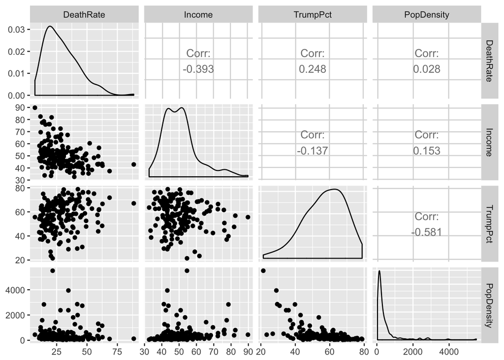

```r
rust.df = data.frame(State, DeathRate, Income, TrumpPct, PopDensity)
ggpairs(rust.df[, -1])
```

The only red flag is that population density is extremely right-skewed. We’ll want to take base 10 logs to mitigate this.

## Faceted plots

First I’ll plot death rate against income and facet by Trump percentage.

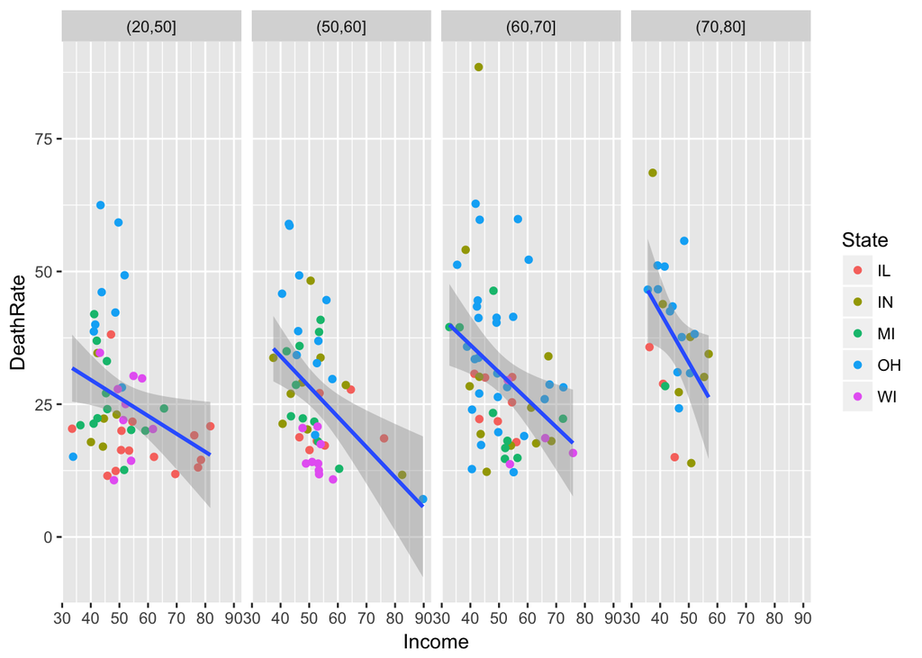

```r
ggplot(rust.df, aes(x = Income, y = DeathRate)) + geom_point(aes(color = State)) +
    geom_smooth(method = "lm") + facet_grid(~cut(TrumpPct, breaks = c(20, 50,
    60, 70, 80)))
```

We see the best fit line shifts upward. The slope seems to get steeper (more negative) as we go from left to right, which is a sign of an interaction.

Let’s now facet two ways, by both Trump percentage and population density.

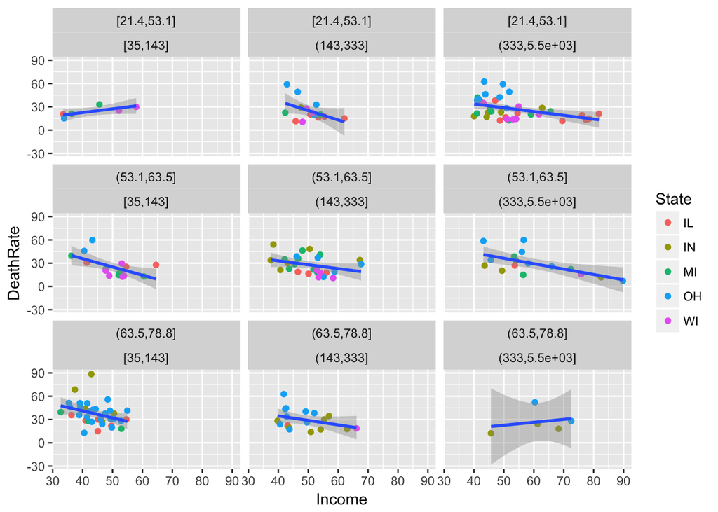

```r
ggplot(rust.df, aes(x = Income, y = DeathRate)) + geom_point(aes(color = State)) +
    geom_smooth(method = "lm") + facet_wrap(~cut_number(TrumpPct, n = 3) + cut_number(PopDensity,
    n = 3))
```

We would want to see if the slopes change in a consistent way as we go from top to bottom. But this is pretty hard to judge, because many of the panels (e.g. high Trump, high density) have few data points and thus noisy fits. It’s probably more secure to make a judgment based on the one-way faceting and include the interaction.

## Model and fit

State actually seems to matter quite a bit, so I’ll include that in the model as well.Try a linear fit with State, Income, TrumpPct, logDensity, and an Income:TrumpPct interaction.

```r
rust.lm = lm(DeathRate ~ State + Income + TrumpPct + log10(PopDensity) + Income:TrumpPct,
    data = rust.df)
```

Because state is additive, it’s sufficient to show the results for one state. Out of personal interest I’ll choose Indiana. First, let’s get an idea of what regions of the explanatories the observed data spans and misses.

```r
Indiana = subset(rust.df, State == "IN")
summary(Indiana)
```

```
##  State     DeathRate         Income         TrumpPct       PopDensity
##  IL: 0   Min.   :11.70   Min.   :37.39   Min.   :35.62   Min.   :  55.44
##  IN:32   1st Qu.:19.05   1st Qu.:42.76   1st Qu.:55.10   1st Qu.: 161.71
##  MI: 0   Median :27.82   Median :47.02   Median :61.99   Median : 283.92
##  OH: 0   Mean   :30.26   Mean   :49.82   Mean   :60.34   Mean   : 391.98
##  WI: 0   3rd Qu.:34.14   3rd Qu.:54.46   3rd Qu.:68.86   3rd Qu.: 448.55
##          Max.   :88.50   Max.   :82.47   Max.   :75.92   Max.   :2375.04
```

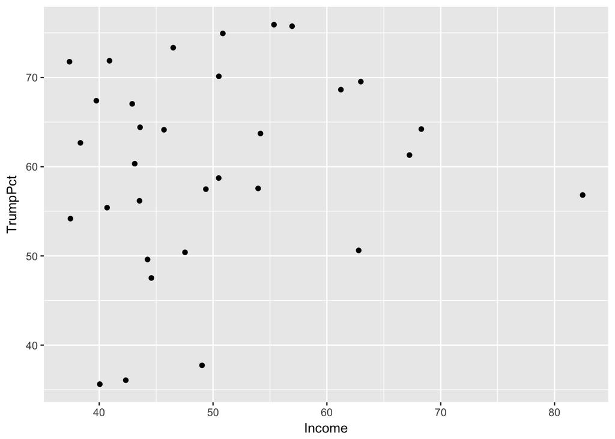

```r
ggplot(Indiana, aes(x = Income, y = TrumpPct)) + geom_point()
```

Make predictions on a grid of income and Trump percentage. Fix the state as Indiana and population density at a typical value of 300 people per square mile.

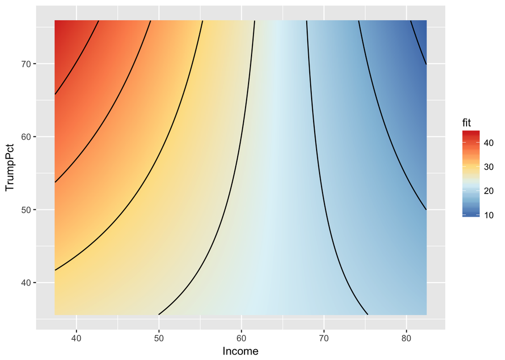

```r
indiana.grid = expand.grid(State = "IN", Income = seq(37.4, 82.4, 0.1), TrumpPct = seq(35.6,
    75.9, 0.1), PopDensity = 300)
indiana.predict = predict(rust.lm, newdata = indiana.grid)
indiana.plot.df = data.frame(indiana.grid, fit = as.vector(indiana.predict))
ggplot(indiana.plot.df, aes(x = Income, y = TrumpPct, z = fit, fill = fit)) +
    geom_raster() + scale_fill_distiller(palette = "RdYlBu") + geom_contour(color = "black")
```

Omit points outside the convex hull:

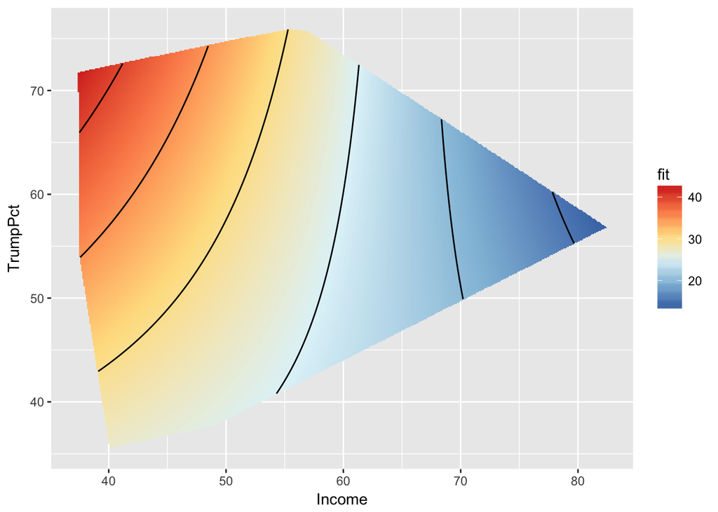

```r
library(interp)
INhull = tri.mesh(Indiana$Income, Indiana$TrumpPct)
crop = in.convex.hull(INhull, indiana.grid$Income, indiana.grid$TrumpPct)
indiana.plot.df2 = indiana.plot.df[crop, ]
ggplot(indiana.plot.df2, aes(x = Income, y = TrumpPct, z = fit, fill = fit)) +
    geom_raster() + scale_fill_distiller(palette = "RdYlBu") + geom_contour(color = "black")
```

The interaction results in non-parallel contours. According to the model, for high income counties, Trump support doesn’t seem to be strongly related to drug deaths (or at least the evidence is inconclusive.) For low income counties, drug deaths seem to increase quite strongly with Trump support. This is unlikely to be causal (for one thing, most 2016 drug deaths happened before the election): instead, it’s a reflection of other factors, perhaps including education, despair, and the availability of health care.